# NON LINEAR REGRESSION MODELS

# Objective

This homework sheet will help reviewing the basic concepts associated with non-linear models. Please review the lectures, suggested readings, and additional resources *before* getting started on the HW.

**Some questions in this assignment will require you to conduct independent research beyond the material covered in the recorded content.**

**Some of the libraries / links mentioned in APPLIED questions are only for your reference. Unless specifically indicated, feel free to utilise any Python library of your choice to carry out the assignment questions**

PYGAM REFERENCE LINK:

https://pygam.readthedocs.io/en/latest/notebooks/tour_of_pygam.html

STATSMODELS REFERENCE LINK:

https://www.statsmodels.org/dev/glm.html

PATSY REFERENCE LINK:

https://patsy.readthedocs.io/en/latest/

The following website has access to the relevant datasets from the recommended textbook: https://book.huihoo.com/introduction-to-statistical-learning/data.html

Marks Distribution

| Question | Marks |
| --- | --- |
| 1a | 0.5 |
| 1b | 0.5 |
| 1c | 0.5 |
| 1d | 0.5 |
| 1e | 0.5 |
| 2 | 1 |
| 3 | 1 |
| 4 | 1 |
| 5a | 0.5 |
| 5b | 0.5 |
| 5c | 0.5 |
| 6a | 2 |
| 6b | 1 |
| 7a | 1 |
| 7b | 2 |
| 7c | 1 |
| 7d | 1 |

# Conceptual

## Question 1

Suppose that a curve $\hat{g}$ is computed to smoothly fit a set of `n` points using the following formula:

$$ \hat{g} = \arg\min_{g}(\sum_{i=1}^n (y_i - g(x_i))^2 + \lambda \int [g^{(m)} (x)]^2 dx ) $$ where $g^{(m)}$ represents the $m^{th}$ derivative of $g$ (and $g^{(0)} = g$. Provide a description (or sketch) of $\hat{g}$ in each of the following scenarios. where $g^{(m)}$ represents the mth derivative of g

(a) $\lambda$ = $\infty$, $m = 0$.

When $\lambda$ = $\infty$, then the optimization problem will essentially becomes

$$\hat{g} = \arg\min_{g}(\sum_{i=1}^n (y_i - g(x_i))^2$$

This case ĝ =0 because a large smoothing parameter forces g(0)(x)→0.

(b) $\lambda$ = $\infty$, $m = 1$.

When $\lambda = \infty$ and $m = 1$, the regularization term dominates the optimization problem, penalizing the first derivative of the curve in this case. when $\lambda = \infty$ optimization problem becomes

$$\hat{g} = \arg\min_{g}(\infty \int [g^{(1)} (x)]^2 dx )$$

when $\lambda = \infty$ and $m = 1$, the optimization problem prioritizes curve smoothness over data fitting, resulting in a smooth curve $\hat{g}$ that minimizes the square of the first derivative

n this case ĝ =c because a large smoothing parameter forces g(1)(x)→0.

(c) $\lambda$ = $\infty$, $m = 2$.

In this case ĝ =cx+d because a large smoothing parameter forces g(2)(x)→0.

(d) $\lambda$ = $\infty$, $m = 3$.

In this case ĝ =cx2+dx+e because a large smoothing parameter forces g(3)(x)→0.

(e) $\lambda$ = 0, $m = 3$.

In this scenario, there is no penalty for the complexity or smoothness of the curve $\hat{g}$. The algorithm aims to find the function $\hat{g}$ that closely fits the data points without any constraints on the derivatives or smoothness, the optimization problem focuses solely on data fitting without considering the smoothness of the curve. The resulting curve $\hat{g}$ may closely follow individual data points, potentially leading to overfitting.

The penalty term doesn’t play any role, so in this case g is the interpolating spline.

## Question 2

For (1) step functions, (2) local regression, and (3) GAMs: provide one situation when using that particular model is advantageous. For instance, “GAMs is likely the preferred option when the question I’m interested in addressing involves…”.

### 1. Step Functions:

#### Advantageous situation:

When you suspect the relationship between features and the target variable might be non-linear and potentially vary locally across different data regions.

#### Example:

Imagine you're modeling stock prices and suspect the price might not follow a simple linear trend over time. Local regression can capture these local trends and potentially adapt to changing relationships over time.

### 2. Local Regression:

#### Advantageous situation:

When you suspect the relationship between features and the target variable might be non-linear and potentially vary locally across different data regions.

#### Example:

Imagine you're modeling stock prices and suspect the price might not follow a simple linear trend over time. Local regression can capture these local trends and potentially adapt to changing relationships over time.

## 3. GAMs (Generalized Additive Models):

#### Advantageous situation:

When you have a mix of linear and non-linear relationships between features and the target variable, and want more flexibility in modeling these relationships.

#### Example:

Imagine you're modeling customer churn based on factors like purchase history (numerical) and satisfaction level (categorical). GAMs can handle the numerical purchase history linearly while potentially capturing a non-linear relationship with the categorical satisfaction level.

## Question 3

Define the following types of smooth functions from PYGAM library (https://pygam.readthedocs.io/en/latest/notebooks/tour_of_pygam.html ) and list at least one relevant potential use:

a) l() linear terms

b) s() spline terms

c) f() factor terms

d) te() Tensor product interaction terms

### a) l() linear terms

#### Definition:

The l() function represents linear terms in a Generalized Additive Model (GAM). It models a linear relationship between a continuous feature (numerical variable) and the target variable.

#### Use Case:

When you have features with a proportional relationship to the target variable. For example, modeling house prices as a function of square footage (assuming price increases linearly with increasing square footage).

### b) s() spline terms

#### Definition:

The s() function represents smooth spline terms in a GAM. It allows for modeling non-linear relationships between a feature and the target variable. Splines are piecewise polynomial functions that provide flexibility in capturing smooth curves.

#### Use Case:

When you suspect a non-linear trend in the data, like modeling sales figures over time (which may exhibit seasonal patterns) or customer churn probability based on a customer's age (which might not be a simple linear increase).

### c) f() factor terms

#### Definition: The f() function represents categorical features (also known as factor variables) in a GAM. It encodes the categories into a set of dummy variables, allowing the model to capture different effects for each category on the target variable.

#### Use Case:

When you have categorical predictors that might influence the target variable in different ways. For example, modeling customer satisfaction based on customer type (bronze, silver, gold) where each category might have a distinct satisfaction level.

### d) te() Tensor product interaction terms

#### Definition: The te() function represents tensor product interaction terms in a GAM. It allows modeling the interaction effect between two or more features. The interaction term captures how the effect of one feature on the target variable changes depending on the level of another feature.

#### Use Case:

When you suspect that the effect of one feature on the target variable depends on the level of another feature. For example, modeling website click-through rate (CTR) considering both user demographics (age) and product category. The CTR for a particular product category might vary depending on the user's age group. By combining these smooth functions in a GAM, you can build flexible and powerful models that capture complex relationships between features and the target variable.

## Question 4

Briefly explain what spatial and temporal autocorrelation are? List one way in which GAMs could help to account for this (e.g. indicate the type of smooth function you would use or potential types of correlation structures).

### Spatial Autocorrelation:

Spatial autocorrelation describes the clustering or patterning of a variable across geographic locations. It measures the degree to which nearby observations are more similar (positive autocorrelation) or dissimilar (negative autocorrelation) compared to random chance.

Example: Disease outbreaks in a city might exhibit positive spatial autocorrelation, indicating higher infection rates in neighboring areas.

### Temporal Autocorrelation:

Temporal autocorrelation describes the correlation of a variable over time. It measures the degree to which observations at close time points are more similar (positive autocorrelation) or dissimilar (negative autocorrelation) compared to random chance.

Example: Stock prices often exhibit positive temporal autocorrelation, meaning past price movements can influence future movements.

### Using GAMs to Account for Autocorrelation

GAMs (Generalized Additive Models) can be a powerful tool to account for autocorrelation issues in both spatial and temporal data analysis. Here's how:

#### 1. Smoothing with Spline Terms (s())

Spline terms in GAMs allow for modeling non-linear trends across space or time. This flexibility can capture underlying spatial or temporal patterns that might contribute to autocorrelation. For example, a spline term for location coordinates in a disease outbreak model could capture spatial clustering, while a spline term for time in a stock price model could capture temporal trends and seasonality.

#### 2. Interaction Terms (te())

Tensor product interaction terms (te()) can incorporate spatial or temporal coordinates as interacting features. This allows the model to capture how the effect of other variables on the target variable changes depending on location or time. For example, you could create an interaction term between a spatial coordinate and a pollution source variable to model how pollution levels vary depending on location relative to the source. Similarly, you could interact a time variable with a weather variable to account for how weather seasonality affects sales.

## Question 5

Consider two curves $\hat{g}1$ and $\hat{g}2$, defined by

$$ \hat{g}1 = \arg\min_{g}(\sum_{i=1}^n (y_i - g(x_i))^2 + \lambda \int [g^{(3)} (x)]^2 dx ) $$

$$ \hat{g}2 = \arg\min_{g}(\sum_{i=1}^n (y_i - g(x_i))^2 + \lambda \int [g^{(4)} (x)]^2 dx ) $$

where $g^{(m)}$ represents the $m^{th}$ derivative of $g$. Now, answer the following questions (and include a brief explanation):

a) As $\lambda \rightarrow \infty$, will $\hat{g}1$ or $\hat{g}2$ have smaller training RSS?

- For both $\hat{g}_1$ and $\hat{g}_2$, the penalty term $\lambda \int [g^{(m)}(x)]^2 dx$ dominates the objective function.
- Since the penalty term penalizes higher-order derivatives of $g$, as $\lambda \rightarrow \infty$, both $\hat{g}_1$ and $\hat{g}_2$ will tend towards smoother functions with smaller derivatives.
- However, since $\hat{g}_2$ has a penalty term on the fourth derivative ($g^{(4)}$) compared to the penalty term on the third derivative ($g^{(3)}$) for $\hat{g}_1$, $\hat{g}_2$ will tend to be smoother than $\hat{g}_1$.
- Therefore, as $\lambda \rightarrow \infty$, $\hat{g}_2$ will have a smaller training Residual Sum of Squares (RSS) compared to $\hat{g}_1$ because it is penalized more for higher-order variations.

b) As $\lambda \rightarrow \infty$, will $\hat{g}1$ or $\hat{g}2$ have smaller test RSS?

- As $\lambda \rightarrow \infty$, both $\hat{g}_1$ and $\hat{g}_2$ will become overly smooth and may not capture the true underlying relationship between the predictors and the response variable well.
- Consequently, both $\hat{g}_1$ and $\hat{g}_2$ are likely to have larger test RSS compared to when $\lambda$ is appropriately chosen (i.e., not too large).
- However, $\hat{g}_2$, being smoother due to the penalty on the fourth derivative, may have a slightly smaller test RSS compared to $\hat{g}_1$ in some cases, but the difference might not be substantial.

c) For $\lambda= 0$, will $\hat{g}1$ or $\hat{g}2$ have smaller training RSS?

- When $\lambda = 0$, the penalty term becomes negligible, and the objective functions reduce to the ordinary least squares (OLS) regression.
- Both $\hat{g}_1$ and $\hat{g}_2$ will be determined solely by the sum of squares of residuals without any penalty for the smoothness of the functions.
- Since $\hat{g}_2$ has a penalty term on the fourth derivative, it might try to fit the data more closely, potentially resulting in a smaller training RSS compared to $\hat{g}_1$.
- Therefore, for $\lambda = 0$, $\hat{g}_2$ is likely to have a smaller training RSS compared to $\hat{g}_1$.

APPLIED

## Question 6

This question relates to the `College` data set.

pre process the data if required

a) Fit a GAM on the training data, using out-of-state tuition as the response and only subset of features as the predictors ( Select 'private', 'Room.Board' , 'PhD' , 'perc.alumni' , 'Expend' , 'Grad.rate' ) Plot the results and briefly explain your findings

```
Private        0
Room.Board     0
PhD            0
perc.alumni    0
Expend         0
Grad.Rate      0
Outstate       0
dtype: int64
```

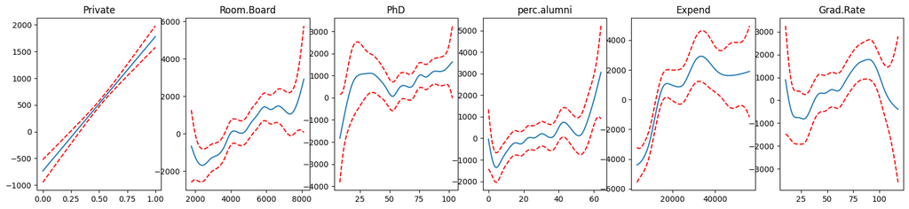

```
LinearGAM
=============================================== ==========================================================
Distribution:                        NormalDist Effective DoF:                                     56.4153
Link Function:                     IdentityLink Log Likelihood:                                -12397.8357
Number of Samples:                          777 AIC:                                            24910.5021
                                                AICc:                                           24919.8369
                                                GCV:                                          3898505.3134
                                                Scale:                                        3392548.1664
                                                Pseudo R-Squared:                                   0.8054
==========================================================================================================
Feature Function                  Lambda               Rank         EDoF         P > x        Sig. Code
================================= ==================== ============ ============ ============ ============
s(0)                              [0.6]                20           3.5          1.11e-16     ***
s(1)                              [0.6]                20           12.0         1.57e-13     ***
s(2)                              [0.6]                20           11.9         7.23e-02     .
s(3)                              [0.6]                20           11.4         7.83e-04     ***
s(4)                              [0.6]                20           8.4          1.11e-16     ***
s(5)                              [0.6]                20           9.3          6.50e-07     ***
intercept                                              1            0.0          1.11e-16     ***
==========================================================================================================
Significance codes:  0 '***' 0.001 '**' 0.01 '*' 0.05 '.' 0.1 ' ' 1

WARNING: Fitting splines and a linear function to a feature introduces a model identifiability problem
         which can cause p-values to appear significant when they are not.

WARNING: p-values calculated in this manner behave correctly for un-penalized models or models with
         known smoothing parameters, but when smoothing parameters have been estimated, the p-values
         are typically lower than they should be, meaning that the tests reject the null too readily.
None
```

```python
import numpy as np
import pandas as pd
import matplotlib.pyplot as plt
from sklearn.preprocessing import LabelEncoder
from pygam import LinearGAM, s

file = "college_w3.csv"

df = pd.read_csv(file)
# print(df.dtypes)
df = df.loc[:, ['Private', 'Room.Board', 'PhD', 'perc.alumni', 'Expend', 'Grad.Rate', 'Outstate']]

label_encoder = LabelEncoder()
df['Private'] = label_encoder.fit_transform(df['Private'])

# print(df.dtypes)
print(df.isnull().sum())

df.head()


X_train = df[['Private', 'Room.Board', 'PhD', 'perc.alumni', 'Expend', 'Grad.Rate']]
y_train = df['Outstate']

gam = LinearGAM(s(0) + s(1) + s(2) + s(3) + s(4) + s(5)).fit(X_train, y_train)

fig, axes = plt.subplots(1, 6, figsize=(20, 4))
for i, ax in enumerate(axes):
    XX = gam.generate_X_grid(term=i)
    ax.plot(XX[:, i], gam.partial_dependence(term=i, X=XX))
    ax.plot(XX[:, i], gam.partial_dependence(term=i, X=XX, width=.95)[1], c='r', ls='--')
    ax.set_title(df.columns[i])
plt.show()


print(gam.summary())
```

b) For which variables, if any, is there evidence of a non-linear relationship with the response?

- Room.Board
- PhD
- perc.alumni
- Expend
- Grad.Rate

They have non-linear relationship.

## Question 7

Answer the questions below using the following dataset (WEEK3_Q7 CSV provided with the learner template):

a) Only by inspecting the plots shown below: Is there any temporal or spatial trend in the response variable `richness`?

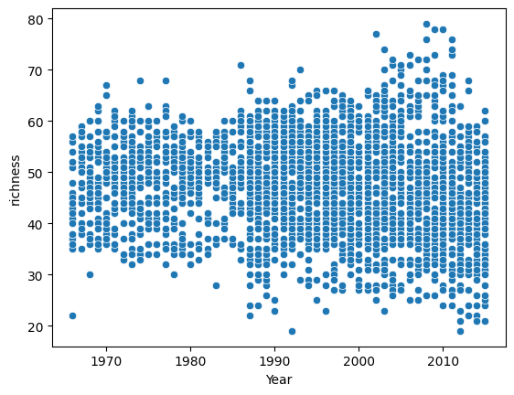

```python
import seaborn as sns
df2 = pd.read_csv("week3-q7.csv")
sns.scatterplot(x=df2.Year,y=df2.richness)
```

I cannot directly identify spatial trends from a scatter plot of richness against year (or any other single variable) because spatial trends relate to variations in data across different geographical locations, not over time.

We can see the temporal trend in the `richness` as it's data for different time and for temporal trend we need data with time so yeah temporal trend is there.

b) Now, fit a Poisson GAM with the following structure `E(richness) = exp(f(year))*exp(g(location))`. Note that location is actually two features: `Longitude` and `Latitude.` Name this model `M1.` Plot the model, get the `summary` of `M1`, and answer: Is there evidence for effects of location and year?

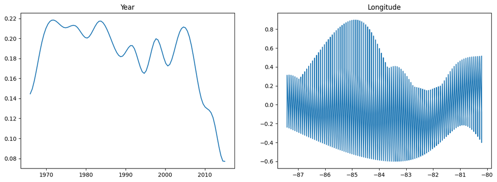

```
PoissonGAM
=============================================== ==========================================================
Distribution:                       PoissonDist Effective DoF:                                     52.3971
Link Function:                          LogLink Log Likelihood:                                  -6544.766
Number of Samples:                         1976 AIC:                                            13194.3263
                                                AICc:                                           13197.3495
                                                UBRE:                                               3.0226
                                                Scale:                                                 1.0
                                                Pseudo R-Squared:                                   0.4674
==========================================================================================================
Feature Function                  Lambda               Rank         EDoF         P > x        Sig. Code
================================= ==================== ============ ============ ============ ============
s(0)                              [0.6]                20           19.5         3.85e-13     ***
te(1, 2)                          [0.6 0.6]            100          32.9         0.00e+00     ***
intercept                                              1            0.0          0.00e+00     ***
==========================================================================================================
Significance codes:  0 '***' 0.001 '**' 0.01 '*' 0.05 '.' 0.1 ' ' 1

WARNING: Fitting splines and a linear function to a feature introduces a model identifiability problem
         which can cause p-values to appear significant when they are not.

WARNING: p-values calculated in this manner behave correctly for un-penalized models or models with
         known smoothing parameters, but when smoothing parameters have been estimated, the p-values
         are typically lower than they should be, meaning that the tests reject the null too readily.
None
```

```python
import pandas as pd
import numpy as np
import matplotlib.pyplot as plt
from pygam import PoissonGAM, s, te
from sklearn.model_selection import train_test_split

data = pd.read_csv("week3-q7.csv")
data.fillna(data.mean(), inplace=True)

X_train, X_test, y_train, y_test = train_test_split(data[['Year', 'Longitude', 'Latitude']], data['richness'], test_size=0.3, random_state=33)

# Preprocessing: Scale the features
# scaler = StandardScaler()
# X_scaled = scaler.fit_transform(X)

M1 = PoissonGAM(s(0) + te(1, 2)).fit(X_train, y_train)

plt.figure()
fig, axs = plt.subplots(1, 2, figsize=(15, 5))

titles = list(X_train.columns.values)
for i, ax in enumerate(axs):
    XX = M1.generate_X_grid(term=i)
    ax.plot(XX[:, i], M1.partial_dependence(term=i, X=XX))
    ax.set_title(titles[i])

plt.show()

print(M1.summary())
```

c) Now, fit another Poisson GAM model with the same structure as in `M1` , name this model `M2` but using interactions between Year, Latitude and Longitude

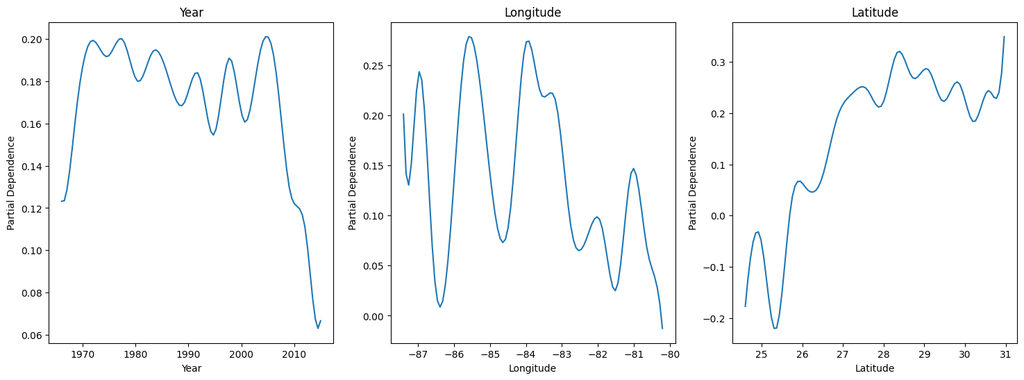

```
PoissonGAM
=============================================== ==========================================================
Distribution:                       PoissonDist Effective DoF:                                     55.4221
Link Function:                          LogLink Log Likelihood:                                 -6551.9207
Number of Samples:                         1976 AIC:                                            13214.6856
                                                AICc:                                            13218.063
                                                UBRE:                                               3.0341
                                                Scale:                                                 1.0
                                                Pseudo R-Squared:                                   0.4633
==========================================================================================================
Feature Function                  Lambda               Rank         EDoF         P > x        Sig. Code
================================= ==================== ============ ============ ============ ============
s(0)                              [0.6]                20           19.5         2.37e-12     ***
s(1)                              [0.6]                20           18.3         0.00e+00     ***
s(2)                              [0.6]                20           17.6         0.00e+00     ***
intercept                                              1            0.0          0.00e+00     ***
==========================================================================================================
Significance codes:  0 '***' 0.001 '**' 0.01 '*' 0.05 '.' 0.1 ' ' 1

WARNING: Fitting splines and a linear function to a feature introduces a model identifiability problem
         which can cause p-values to appear significant when they are not.

WARNING: p-values calculated in this manner behave correctly for un-penalized models or models with
         known smoothing parameters, but when smoothing parameters have been estimated, the p-values
         are typically lower than they should be, meaning that the tests reject the null too readily.
None
```

```python
import pandas as pd
import numpy as np
import matplotlib.pyplot as plt
from pygam import PoissonGAM, s, te
from sklearn.preprocessing import StandardScaler

data = pd.read_csv("week3-q7.csv")

data.fillna(data.mean(), inplace=True)

M2 = PoissonGAM(s(0) + s(1) + s(2)).fit(X_train, y_train)

plt.figure()
fig, axs = plt.subplots(1, 3, figsize=(18, 6))

titles = list(X_train.columns.values)
for i, ax in enumerate(axs):
    XX = M2.generate_X_grid(term=i)
    ax.plot(XX[:, i], M2.partial_dependence(term=i, X=XX))
    ax.set_title(titles[i])
    ax.set_xlabel(titles[i])
    ax.set_ylabel('Partial Dependence')

plt.show()

print(M2.summary())
```

d) Compare `M1` and `M2`. Note that you can use the $R^2$, AIC values, test error, among other approaches discussed in class. Which model should we select?

```python
from sklearn.metrics import r2_score, mean_squared_error

y_pred_M1 = M1.predict(X_test)
y_pred_M2 = M2.predict(X_test)

M1_resd = y_test - y_pred_M1
M2_resd = y_test - y_pred_M2

d1 = np.sum(np.power(M1_resd, 2))
d2 = np.sum(np.power(M2_resd, 2))

AIC_M1 = M1.statistics_['AIC']
AIC_M2 = M2.statistics_['AIC']

R2_M1 = r2_score(y_test, y_pred_M1)
R2_M2 = r2_score(y_test, y_pred_M2)

MSE_M1 = mean_squared_error(y_test, y_pred_M1)
MSE_M2 = mean_squared_error(y_test, y_pred_M2)

print("Deviance for M1 on test set:", d1)
print("Deviance for M2 on test set:", d2)
print("AIC for M1:", AIC_M1)
print("AIC for M2:", AIC_M2)
print("R-squared for M1:", R2_M1)
print("R-squared for M2:", R2_M2)
print("MSE for M1:", MSE_M1)
print("MSE for M2:", MSE_M2)

if d1 < d2 and AIC_M1 < AIC_M2 and R2_M1 > R2_M2 and MSE_M1 < MSE_M2:
    print("M1 indicating a better fit.")
    best_model = M1
elif d1 > d2 and AIC_M1 > AIC_M2 and R2_M1 < R2_M2 and MSE_M1 > MSE_M2:
    print("M2 indicating a better fit.")
    best_model = M2
else:
    print("Unknown")
```

```
Deviance for M1 on test set: 39669.132712252496
Deviance for M2 on test set: 40399.74592540025
AIC for M1: 13194.326308193884
AIC for M2: 13214.685592060127
R-squared for M1: 0.43196865622389513
R-squared for M2: 0.4215068392677429
MSE for M1: 46.77963763237322
MSE for M2: 47.64120981768898
M1 indicating a better fit.
```